# Col de la Porte

#### Model: GEOtop v3.0

Compiler: gcc version 4.8.4 (Ubuntu 4.8.4-2ubuntu1~14.04.1) Processor: Intel(R) Core(TM) i7-5500U CPU @ 2.40GHz Author: Stefano Endrizzi (stefano.end@gmail.com),Emanuele Cordano (emanuele.cordano@rendena100.eu) Date: 25-11-2016

#### Name: ColdelaPorte

Description: Simulation 1D over the Col de la Porte dataset to test the capability of GEOotp to simulate snow depth, snow water equivalent, soil temperature.

#### Results published in:

- Snow Height (Snow Dapth);
- Snow Water Equivalent;
- Soil Temperature at 10 cm depth;
- Soil temparature at 20 cm depth;
- Soil Temparature at 50 cm depth;
- Surface Temparature ;
- Albedo .

#### Observations published in:

see Morin et al. (2012)

[figure not shown]

```r
plot(cars)
```

### Output:

PointOutputFile = “output-tabs/surface”

```r
library(geotopbricks)
library(magrittr)
```

```r
library(reshape2)
wpath <- '/home/ecor/activity/2020/geotop_article/git/GEOtopExamples/tests/ColdelaPorte/sims'
wpaths <- wpath %>% list.files(pattern="sim",full.name=TRUE)
names(wpaths) <- wpath %>% list.files(pattern="sim",full.name=FALSE)
outvar <- c("Tair.C.","Tsurface.C.","snow_depth.mm.","snow_water_equivalent.mm.")
date_field <- "Date12.DDMMYYYYhhmm."
tz <- "Etc/GMT-1"

get_out <- function(wpath,outvar=outvar,...){

  o <- get.geotop.inpts.keyword.value("PointOutputFile",data.frame=TRUE,wpath=wpath,...)

   o <- o[,outvar]
   ## zoo to dataframe
   nn <- names(o)
   time <- index(o)
   o <- as.data.frame(o)
   o$time <- as.POSIXct(time)
   ###index(o) <- NULL
   o <-o[,c("time",nn)]
   oo <- o
   return(o)
}
##out_v2 <- wpaths %>% lapply(FUN=get_out,add_suffix_dir="_v2",outvar=outvar)
out_v3 <- wpaths %>% lapply(FUN=get_out,add_suffix_dir="_v3",outvar=outvar,date_field=date_field,tz=tz) %>% melt(id="time")


#out <-"PointOutputFile" %>% mapply(FUN=get.geotop.inpts.keyword.value,wpath=wpaths,SIMPLIFY = FALSE,data.frame=TRUE)


knitr::kable(out_v3[1000+100:105,])
```

|  | time | variable | value | L1 |
| --- | --- | --- | --- | --- |
| 1100 | 2001-02-15 20:00:00 | Tair.C. | 3.9 | sim_1 |
| 1101 | 2001-02-15 21:00:00 | Tair.C. | 4.0 | sim_1 |
| 1102 | 2001-02-15 22:00:00 | Tair.C. | 4.5 | sim_1 |
| 1103 | 2001-02-15 23:00:00 | Tair.C. | 4.5 | sim_1 |
| 1104 | 2001-02-16 00:00:00 | Tair.C. | 3.9 | sim_1 |
| 1105 | 2001-02-16 01:00:00 | Tair.C. | 3.2 | sim_1 |

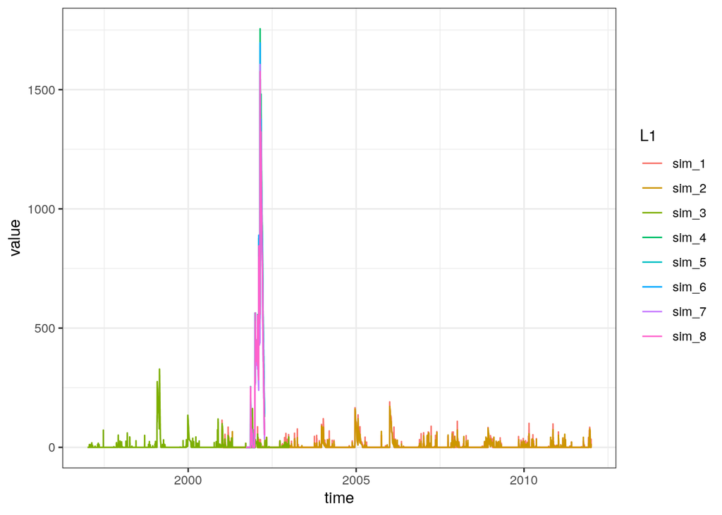

```r
library(ggplot2)
library(dplyr)
varname <- "snow_depth.mm."
out <- out_v3 %>% filter(variable==varname)
g <- ggplot()+geom_line(aes(x=time,y=value,group=L1,col=L1),data=out)+theme_bw()
g
```

### Observations:

Snow heigth mm, Snow Water Equivalent mm, T surface C, T soil 10cm C,T soil 20cm C,T soil 50cm C

### References

Endrizzi, S., S. Gruber, M. Dall’Amico, and R. Rigon. 2014. “GEOtop 2.0: Simulating the Combined Energy and Water Balance at and Below the Land Surface Accounting for Soil Freezing, Snow Cover and Terrain Effects.” *Geoscientific Model Development* 7 (6): 2831–57. https://doi.org/10.5194/gmd-7-2831-2014.

Morin, S., Y. Lejeune, B. Lesaffre, J.-M. Panel, D. Poncet, P. David, and M. Sudul. 2012. “An 18-Yr Long (1993â€“2011) Snow and Meteorological Dataset from a Mid-Altitude Mountain Site (Col de Porte, France, 1325 M Alt.) for Driving and Evaluating Snowpack Models.” *Earth System Science Data* 4 (1): 13–21. https://doi.org/10.5194/essd-4-13-2012.